# Final Project: Breast Cancer Data Analysis

2025-12-02

## Evangeline M. Bollard

# Raw Data

The original data set included information on each breast cancer sample taken from a patient. Other non-identifying but important attributes are also listed including: gender, diagnosis age, hormone receptor status, & tumor stage.

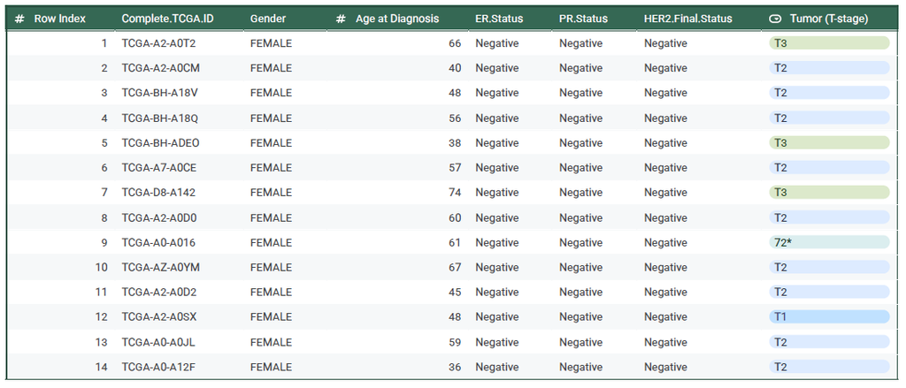

Figure 1. Raw data

# Data Simplification

I simplified this data set to analyze the different stages and sub-stages of breast cancer using three therapeutic targets, Estrogen Receptors, Progesterone Receptors, and Human Epidermal growth factor receptor 2 or HER2. This approach is an effective strategy because the status of these therapeutic targets is the key factor to determine a treatment strategy for each breast cancer patient. The combination of these types creates molecular sub-types of breast cancer that each have their own best therapy treatment.

# Cleaned Data

The resulting clean data is organized by AJCC stage (the system used to describe the extent of cancer in a patient’s body) therapeutic target status, and patient count for each combination of factors.

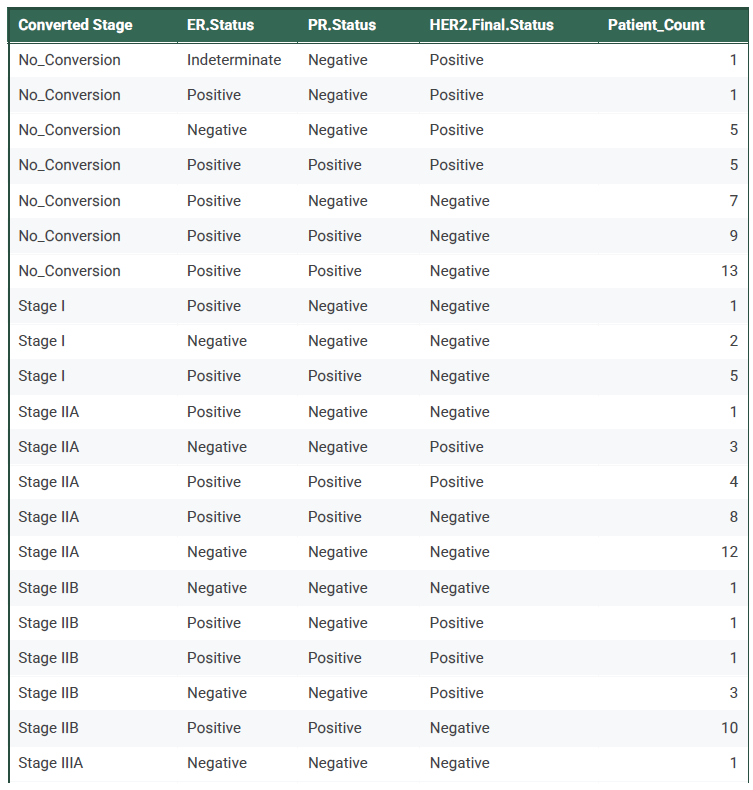

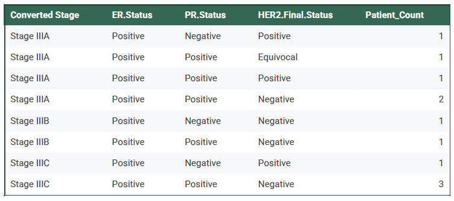

## Subtypes of Breast Cancer and Best Treatment

In Hormone Receptor positive and HER2 negative cases, hormone therapy is used because estrogen and progesterone receptors have their growth controlled by hormones. Hormone therapy can either lower estrogen or progesterone levels or by blocking the receptors entirely. In HER2 positive cases, the cancer cells make too much HER2 protein on their surface which allows them to grow exponentially. In these cases, the cells are treated with anti-HER2 targeted therapy that bonds to the HER2 receptors on the cancer cell surface and blocks the growth signals. In Triple Negative Breast Cancers (ER-, PR- and HER2-), these cancer cells lack all three receptors. Because they don’t have specific targets, targeted therapy doesn’t work. Therefore, these cells are treated with more generalized treatments like chemotherapy or immunotherapy.

[figure not shown]

Figure 3. Types of Breast Cancer

# Installing packages

These are the packages I needed to install for this project.

```r
library(tidyverse)
library(dplyr)
library(survival)
library(survminer)
library(ggplot2)
```

# Analysis

With the data in a usable format, it allows us to see the prevalence of the therapeutic sub-types at different stages of breast cancer. The most important metric for breast cancer is the presence of a therapeutic target. Some cancers do not have any of the three receptors, and therefore does not respond to hormonal or HER2 targeted therapies. These types of cancer are extremely aggressive, recur more often, and have a higher probability of mortality.

[figure not shown]

No conversion means there is a failure of a treatment to change the tumor’s status from having unfavorable characteristics to a state where curative intervention is possible. Stage I is where there is a small, localized tumor that has not spread. Stage IIA means the cancer is advanced but has not metastasized. Stage IIB means the tumor is invasive based on size (between 2-5 cm) with a spread to 1 to 3 lymph nodes. Stage IIIA is when the cancer has spread to the lymph nodes but has not spread to distant organs. Stage IIIB means the cancer has spread into the chest wall or skin of the breast. Stage IIIC means the cancer has spread to 10 or more lymph nodes, but not distant organs.

[figure not shown]

Figure 5. Proportion of TNBC by Cancer Stage

# Survivability

Another metric that was examined was the survivability of the different sub-types of breast cancer at each stage. By analyzing the data across stages and sub-stages, we can better understand how the tumor changes as the disease progresses and how that affects outcomes. The best existing model to estimate survival after treatment is called the Kaplan-Meier survival model. The KM model estimates the probability of survival over specific periods of time and is visualized with a step-wise curve.

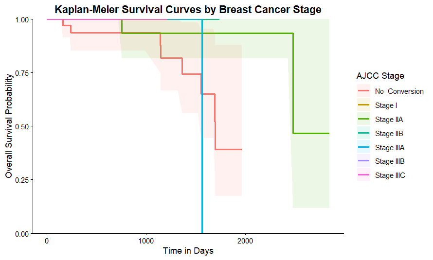